# Projeto 2

### 1 –Considere os dados gerados com a função:

### skdata.make_moons(n_samples=n_samples, noise=p)

### Construa um gráfico da acurácia versus a taxa de ruído para os algoritmos random forest e redes neurais. Considerem uma média de ao menos 10 simulações.

```python
import random
random.seed(1)
import pandas as pd
import numpy as np
import matplotlib.pyplot as plt
```

```python
from sklearn.ensemble import RandomForestClassifier
from sklearn.datasets import make_classification
from sklearn.model_selection import train_test_split
from sklearn.metrics import accuracy_score

def randomForestMeanScore (X, Y, n_estimators=100, p=0.7, Ns=10):
    score_rf = []
    for i in range(0, Ns):
        train_x, test_x, train_y, test_y = train_test_split(X, Y, test_size = 1-p, random_state=42)
        rf = RandomForestClassifier(n_estimators, max_depth=2, random_state=0)
        rf.fit(train_x, train_y)
        pred_y = rf.predict(test_x)
        score_rf.append(accuracy_score(pred_y, test_y))
        return np.mean(score_rf)
```

```python
from sklearn.preprocessing import MinMaxScaler
from sklearn.neural_network import MLPClassifier
from sklearn.metrics import accuracy_score

def neuralNetworkMeanScore (X, Y, hidden_layer_sizes=(100, 100), p = 0.7, solver='lbfgs', Ns=10):
    score_nn = []
    for i in range(0, Ns):
        train_x, test_x, train_y, test_y = train_test_split(X, Y, test_size = 1-p, random_state = 42)
        scaler = MinMaxScaler()
        scaler.fit(train_x.astype(float))
        train_x = scaler.transform(train_x)
        # apply same transformation to test data
        test_x = scaler.transform(test_x)
        clf = MLPClassifier(hidden_layer_sizes, 'relu', solver, alpha=1e-5,  random_state=1, max_iter=500)# Train the model on training data
        clf.fit(train_x, train_y);
        pred_y = clf.predict(test_x)
        score_nn.append(accuracy_score(pred_y, test_y))
    return np.mean(score_nn)
```

Gerando os conjuntos de dados utilizando skdata.make_moons variando a porcentagem de ruído para analisar os classificadores:

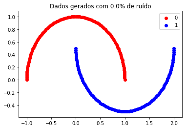

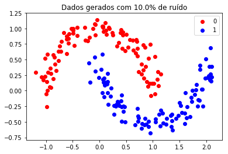

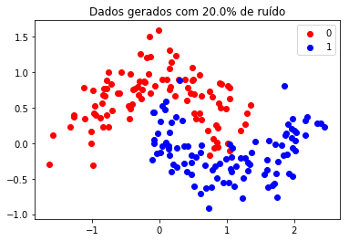

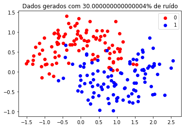

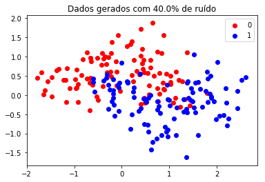

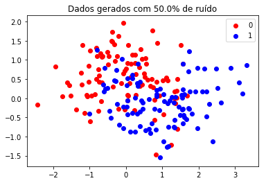

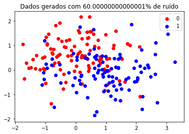

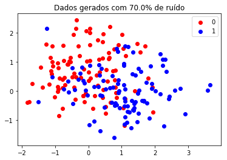

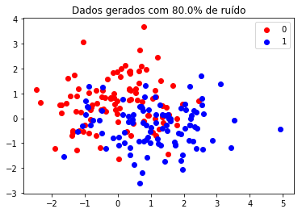

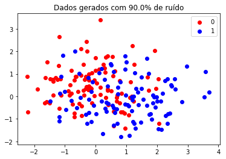

```python
import sklearn.datasets as skdata
from matplotlib import pyplot
from pandas import DataFrame
# generate 2d classification dataset
n_samples = 200
n_bins = 3  # use 3 bins for calibration_curve as we have 3 clusters here
centers = [(-4, 0), (0, 0), (3, 3)]

acuracia_rf = []
acuracia_nn = []
noise = []

for i in np.arange(0, 1, 0.1):
    noise.append(i)
    X, y = skdata.make_moons(n_samples=n_samples, noise=i)


    d = np.column_stack((X,np.transpose(y)))
    data = DataFrame(data = d, columns=['X1', 'X2', 'y'])
    features_names = ['X1', 'X2']
    class_labels = np.unique(y)
    #Plotting
    colors = ['red', 'blue', 'green', 'black']
    aux = 0
    for c in class_labels:
        ind = np.where(y == c)
        plt.scatter(X[ind, 0][0], X[ind,1][0], color = colors[aux], label = c)
        aux = aux + 1
    plt.title("Dados gerados com " + str(i*100) + "% de ruído")
    plt.legend()
    plt.show()

    Y = np.array(data[data.columns[-1]],dtype=str)
    data= data.drop(data.columns[-1], axis = 1)
    feature_list = list(data.columns)
    X = np.array(data)

    acuracia_rf.append(randomForestMeanScore (X, Y, p = 0.7, Ns=10))
    acuracia_nn.append(neuralNetworkMeanScore(X, Y, p = 0.7, Ns=10))
```

Gráfico da acurácia versus a taxa de ruído para os algoritmos random forest e redes neurais:

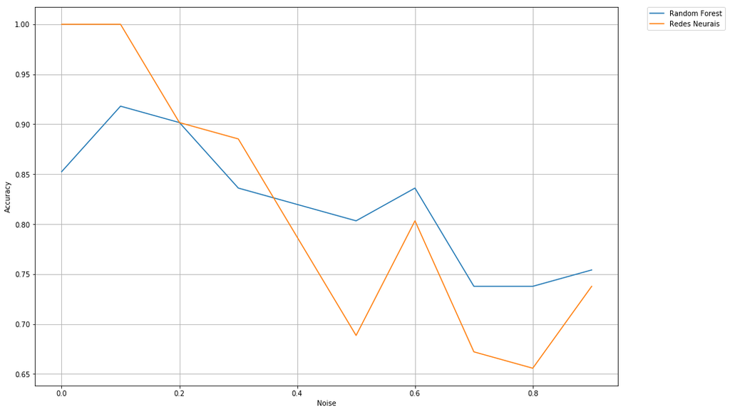

```python
plt.figure(figsize=(15,10))
plt.xlabel("Noise")
plt.ylabel("Accuracy")
plt.plot(noise, acuracia_rf, label='Random Forest')
plt.plot(noise, acuracia_nn, label='Redes Neurais')
plt.legend(bbox_to_anchor=(1.05, 1), loc=2, borderaxespad=0.)
plt.grid(True)
plt.show(True)
```

### 2 - No caso do algoritmo random forest, faça um gráfico da acurácia em função do número de árvores para a base Vehicle. Considere uma média de ao menos 10 simulações.

```python
import random
random.seed(1)
# Pandas is used for data manipulation
import pandas as pd
import matplotlib.pyplot as plt
import numpy as np

#CSV file
features = pd.read_csv("Vehicle.csv", header=(0))
print(features.shape)
features.head(10)
```

```
(846, 19)
```

|  | Comp | Circ | D.Circ | Rad.Ra | Pr.Axis.Ra | Max.L.Ra | Scat.Ra | Elong | Pr.Axis.Rect | Max.L.Rect | Sc.Var.Maxis | Sc.Var.maxis | Ra.Gyr | Skew.Maxis | Skew.maxis | Kurt.maxis | Kurt.Maxis | Holl.Ra | Class |
| --- | --- | --- | --- | --- | --- | --- | --- | --- | --- | --- | --- | --- | --- | --- | --- | --- | --- | --- | --- |
| 0 | 95 | 48 | 83 | 178 | 72 | 10 | 162 | 42 | 20 | 159 | 176 | 379 | 184 | 70 | 6 | 16 | 187 | 197 | van |
| 1 | 91 | 41 | 84 | 141 | 57 | 9 | 149 | 45 | 19 | 143 | 170 | 330 | 158 | 72 | 9 | 14 | 189 | 199 | van |
| 2 | 104 | 50 | 106 | 209 | 66 | 10 | 207 | 32 | 23 | 158 | 223 | 635 | 220 | 73 | 14 | 9 | 188 | 196 | saab |
| 3 | 93 | 41 | 82 | 159 | 63 | 9 | 144 | 46 | 19 | 143 | 160 | 309 | 127 | 63 | 6 | 10 | 199 | 207 | van |
| 4 | 85 | 44 | 70 | 205 | 103 | 52 | 149 | 45 | 19 | 144 | 241 | 325 | 188 | 127 | 9 | 11 | 180 | 183 | bus |
| 5 | 107 | 57 | 106 | 172 | 50 | 6 | 255 | 26 | 28 | 169 | 280 | 957 | 264 | 85 | 5 | 9 | 181 | 183 | bus |
| 6 | 97 | 43 | 73 | 173 | 65 | 6 | 153 | 42 | 19 | 143 | 176 | 361 | 172 | 66 | 13 | 1 | 200 | 204 | bus |
| 7 | 90 | 43 | 66 | 157 | 65 | 9 | 137 | 48 | 18 | 146 | 162 | 281 | 164 | 67 | 3 | 3 | 193 | 202 | van |
| 8 | 86 | 34 | 62 | 140 | 61 | 7 | 122 | 54 | 17 | 127 | 141 | 223 | 112 | 64 | 2 | 14 | 200 | 208 | van |
| 9 | 93 | 44 | 98 | 197 | 62 | 11 | 183 | 36 | 22 | 146 | 202 | 505 | 152 | 64 | 4 | 14 | 195 | 204 | saab |

```python
features = features.dropna()
features.duplicated()
features = features.drop_duplicates()
features = features.replace('?', np.nan)
features = features.dropna()
classes = pd.unique(features[features.columns[-1]]) #name of the classes
classes = np.array(classes, dtype=str) #convert on array
print("Classes únicas no conjunto de dados:", classes)
list_labels = list(features.columns)
print("\nNomes dos atributos e classe:",list_labels)
```

```
Classes únicas no conjunto de dados: ['van' 'saab' 'bus' 'opel']

Nomes dos atributos e classe: ['Comp', 'Circ', 'D.Circ', 'Rad.Ra', 'Pr.Axis.Ra', 'Max.L.Ra', 'Scat.Ra', 'Elong', 'Pr.Axis.Rect', 'Max.L.Rect', 'Sc.Var.Maxis', 'Sc.Var.maxis', 'Ra.Gyr', 'Skew.Maxis', 'Skew.maxis', 'Kurt.maxis', 'Kurt.Maxis', 'Holl.Ra', 'Class']
```

```python
Y = np.array(features[list_labels[-1]], dtype=str)
#Convert to numpy array
X = np.array(features)
#Remove the labels from the features
#axis 1 refers to the columns
features = features.drop(list_labels[-1], axis = 1)
#Remove feature time
feabtures = features.drop(list_labels[0], axis = 1)
features.head(10)
```

|  | Comp | Circ | D.Circ | Rad.Ra | Pr.Axis.Ra | Max.L.Ra | Scat.Ra | Elong | Pr.Axis.Rect | Max.L.Rect | Sc.Var.Maxis | Sc.Var.maxis | Ra.Gyr | Skew.Maxis | Skew.maxis | Kurt.maxis | Kurt.Maxis | Holl.Ra |
| --- | --- | --- | --- | --- | --- | --- | --- | --- | --- | --- | --- | --- | --- | --- | --- | --- | --- | --- |
| 0 | 95 | 48 | 83 | 178 | 72 | 10 | 162 | 42 | 20 | 159 | 176 | 379 | 184 | 70 | 6 | 16 | 187 | 197 |
| 1 | 91 | 41 | 84 | 141 | 57 | 9 | 149 | 45 | 19 | 143 | 170 | 330 | 158 | 72 | 9 | 14 | 189 | 199 |
| 2 | 104 | 50 | 106 | 209 | 66 | 10 | 207 | 32 | 23 | 158 | 223 | 635 | 220 | 73 | 14 | 9 | 188 | 196 |
| 3 | 93 | 41 | 82 | 159 | 63 | 9 | 144 | 46 | 19 | 143 | 160 | 309 | 127 | 63 | 6 | 10 | 199 | 207 |
| 4 | 85 | 44 | 70 | 205 | 103 | 52 | 149 | 45 | 19 | 144 | 241 | 325 | 188 | 127 | 9 | 11 | 180 | 183 |
| 5 | 107 | 57 | 106 | 172 | 50 | 6 | 255 | 26 | 28 | 169 | 280 | 957 | 264 | 85 | 5 | 9 | 181 | 183 |
| 6 | 97 | 43 | 73 | 173 | 65 | 6 | 153 | 42 | 19 | 143 | 176 | 361 | 172 | 66 | 13 | 1 | 200 | 204 |
| 7 | 90 | 43 | 66 | 157 | 65 | 9 | 137 | 48 | 18 | 146 | 162 | 281 | 164 | 67 | 3 | 3 | 193 | 202 |
| 8 | 86 | 34 | 62 | 140 | 61 | 7 | 122 | 54 | 17 | 127 | 141 | 223 | 112 | 64 | 2 | 14 | 200 | 208 |
| 9 | 93 | 44 | 98 | 197 | 62 | 11 | 183 | 36 | 22 | 146 | 202 | 505 | 152 | 64 | 4 | 14 | 195 | 204 |

```python
cl = np.unique(Y)
ncl = np.zeros(len(cl))
for i in np.arange(0, len(cl)):
    a = Y == cl[i]
    ncl[i] = len(Y[a])
print(ncl)
```

```
[218. 212. 217. 199.]
```

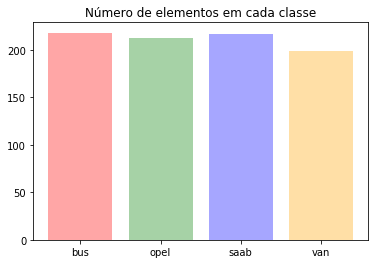

```python
numbers = np.arange(0, len(cl))
plt.bar(numbers, ncl, alpha=.35, color=['red', 'green', 'blue', 'orange', 'cyan'])
plt.xticks(numbers, cl)
plt.title('Número de elementos em cada classe')
plt.show(True)
```

```python
#Saving feature names for later use
feature_list = list(features.columns)
print(feature_list)
```

```
['Comp', 'Circ', 'D.Circ', 'Rad.Ra', 'Pr.Axis.Ra', 'Max.L.Ra', 'Scat.Ra', 'Elong', 'Pr.Axis.Rect', 'Max.L.Rect', 'Sc.Var.Maxis', 'Sc.Var.maxis', 'Ra.Gyr', 'Skew.Maxis', 'Skew.maxis', 'Kurt.maxis', 'Kurt.Maxis', 'Holl.Ra']
```

```python
#Convert to numpy array
X = np.array(features)
```

```
Acurácia versus o número de árvores para o Random Forest:
```

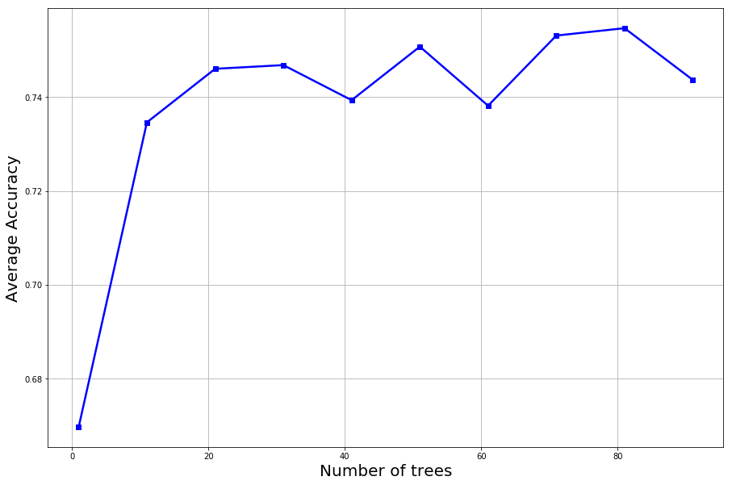

```python
from sklearn.ensemble import RandomForestClassifier
from sklearn.datasets import make_classification
from sklearn.model_selection import train_test_split
from sklearn.metrics import accuracy_score

estimators = np.arange(1, 100, 10)
scores = []
Ns = 10 #number of simulations
for n in estimators:
    p = 0.7
    accuracy = []
    for s in range(0,Ns): #Average over Ns simulations
        train_x, test_x, train_y, test_y = train_test_split(X, Y, test_size = 1-p)
        rf = RandomForestClassifier(n_estimators=n, random_state=0)
        rf.fit(train_x, train_y)
        pred_y = rf.predict(test_x)
        accuracy.append(accuracy_score(pred_y, test_y))
    scores.append(np.mean(accuracy))
plt.figure(figsize=(15,10))
plt.plot(estimators, scores, marker='s', linestyle='-', color="blue", linewidth=2.5)
print("Acurácia versus o número de árvores para o Random Forest:")
plt.xlabel("Number of trees", fontsize=20)
plt.ylabel("Average Accuracy", fontsize=20)
plt.grid(True)
plt.show(True)
```

### 3 - Verifique a influencia do número de camadas da rede neural na classificação para a base Vehicle. Considere o exemplo mostrado acima.

```
Layers: (10,)
Layers: (10, 10)
Layers: (10, 10, 10)
Layers: (10, 10, 10, 10)
Layers: (10, 10, 10, 10, 10)
Layers: (10, 10, 10, 10, 10, 10)
Layers: (10, 10, 10, 10, 10, 10, 10)
Layers: (10, 10, 10, 10, 10, 10, 10, 10)
Layers: (10, 10, 10, 10, 10, 10, 10, 10, 10)
Layers: (10, 10, 10, 10, 10, 10, 10, 10, 10, 10)
Layers: (10, 10, 10, 10, 10, 10, 10, 10, 10, 10, 10)
Layers: (10, 10, 10, 10, 10, 10, 10, 10, 10, 10, 10, 10)
Layers: (10, 10, 10, 10, 10, 10, 10, 10, 10, 10, 10, 10, 10)
Layers: (10, 10, 10, 10, 10, 10, 10, 10, 10, 10, 10, 10, 10, 10)
Layers: (10, 10, 10, 10, 10, 10, 10, 10, 10, 10, 10, 10, 10, 10, 10)
Layers: (10, 10, 10, 10, 10, 10, 10, 10, 10, 10, 10, 10, 10, 10, 10, 10)
Layers: (10, 10, 10, 10, 10, 10, 10, 10, 10, 10, 10, 10, 10, 10, 10, 10, 10)
Layers: (10, 10, 10, 10, 10, 10, 10, 10, 10, 10, 10, 10, 10, 10, 10, 10, 10, 10)
Layers: (10, 10, 10, 10, 10, 10, 10, 10, 10, 10, 10, 10, 10, 10, 10, 10, 10, 10, 10)
Layers: (10, 10, 10, 10, 10, 10, 10, 10, 10, 10, 10, 10, 10, 10, 10, 10, 10, 10, 10, 10)



Influencia do número de camadas da rede neural na classificação para a base Vehicle:
```

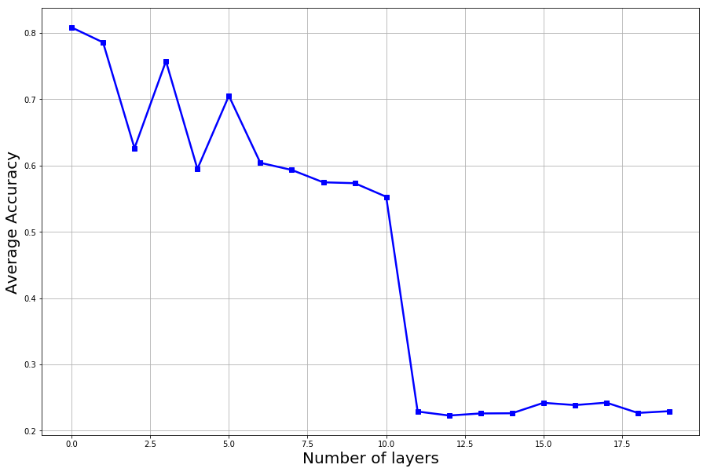

```python
from sklearn.neural_network import MLPClassifier
nneurons = 10
vscore = []
vlayers = []
slayers = range(20) # number of layers
Ns = 15 #Number of simulations
layers = (nneurons,) # We'll have to append to this tupple each interaction
for nl in slayers:
    print('Layers:', layers)
    layers=layers+(nneurons,) # increase the number of layers
    p = 0.7
    accuracy = []
    for s in range(0,Ns): #Average over Ns simulations
        train_x, test_x, train_y, test_y = train_test_split(X, Y, test_size = 1-p)
        scaler = MinMaxScaler()
        scaler.fit(train_x.astype(float))
        train_x = scaler.transform(train_x)
        test_x = scaler.transform(test_x)
        clf = MLPClassifier(solver='lbfgs', alpha=1e-5,hidden_layer_sizes=layers, random_state=1)
        clf.fit(train_x, train_y);
        pred_y = clf.predict(test_x)
        accuracy.append(accuracy_score(pred_y, test_y))
    vscore.append(np.mean(accuracy))
plt.figure(figsize=(15,10))
plt.plot(slayers, vscore, marker='s', linestyle='-', color="blue", linewidth=2.5)
print("\n\n")
print("Influencia do número de camadas da rede neural na classificação para a base Vehicle:")
plt.xlabel("Number of layers", fontsize=20)
plt.ylabel("Average Accuracy", fontsize=20)
plt.grid(True)
plt.show(True)
```

### 4 - Analise outras funções que definem o parâmetro solver da rede neural e compare os resultados para a base Vehicle. Isto, considere os casos: solver= {‘lbfgs’, ‘sgd’, ‘adam’}. Considere a rede neural com a melhor configuração (número de camadas) no exercício anterior.

```python
nneurons = 10
layers = (nneurons,)
layers=layers+(nneurons,)
score_lbfgs = neuralNetworkMeanScore (X, Y, hidden_layer_sizes=layers, p = 0.7, solver='lbfgs', Ns=10)
score_sgd = neuralNetworkMeanScore (X, Y, hidden_layer_sizes=layers, p = 0.7, solver='sgd', Ns=10)
score_adam = neuralNetworkMeanScore (X, Y, hidden_layer_sizes=layers, p = 0.7, solver='adam', Ns=10)

print("Acurácias para Redes Neurais de duas camadas utilizando o solver:\n")
print("lbgs: \t\t%.4f" %score_lbfgs )
print("sgd: \t\t%.4f" % score_sgd)
print("adam: \t\t%.4f"% score_adam)
```

[output not shown]

```
Acurácias para Redes Neurais de duas camadas utilizando o solver:

lbgs: 		0.8307
sgd: 		0.4291
adam: 		0.7520
```

### 5 - Verifique a influência do tamanho do conjunto de treinamento nos classificadores random forest e neural networks. Essa análise é semelhante à realizada no projeto 1.

```
Gráfico da acurácia em função da fração de elementos no conjunto de treinamento:
```

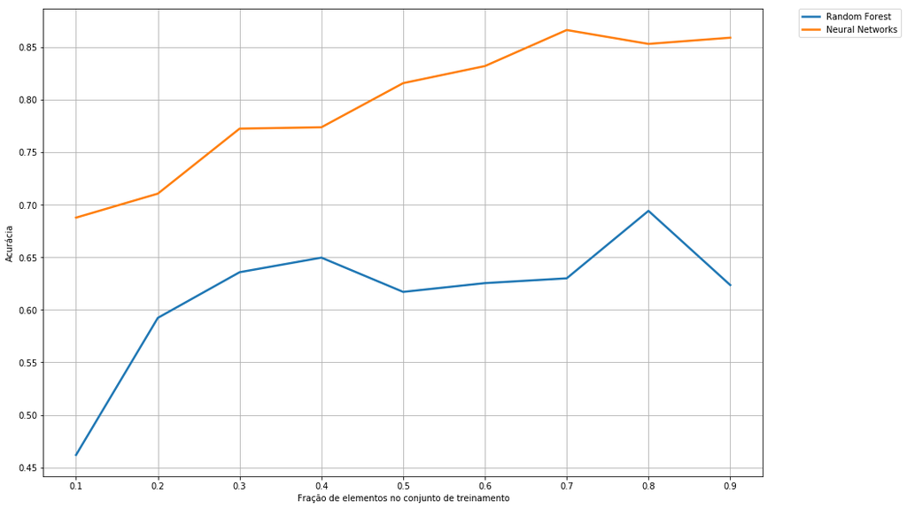

```python
acuracia_rf = []
acuracia_nn = []

list_p = []
for i in range(1, 10):
    list_p.append(i/10)
    acuracia_rf.append(randomForestMeanScore(X, Y, p = i/10))
    acuracia_nn.append(neuralNetworkMeanScore (X, Y, p = i/10))

print("Gráfico da acurácia em função da fração de elementos no conjunto de treinamento:")
plt.figure(figsize=(15,10))
plt.xlabel("Fração de elementos no conjunto de treinamento")
plt.ylabel("Acurácia")
plt.plot(list_p, acuracia_rf, label = 'Random Forest', linewidth=2.5)
plt.plot(list_p, acuracia_nn, label = 'Neural Networks', linewidth=2.5)
plt.legend(bbox_to_anchor=(1.05, 1), loc=2, borderaxespad=0.)
plt.grid(True)
```